# Tugas 3 MPDW

Azzahra Adelia Putri

2023-09-18

## Packages

```r
library(rio)
library(dLagM)
library(dynlm)
library(MLmetrics)
library(lmtest)
library(car)
```

## Impor Data

Peubah x yang digunakan adalah Open dan peubah y yang digunakan adalah High.

```r
data <- import("https://raw.githubusercontent.com/azzhraadelia/PrakMPDW/main/Pertemuan%203/Data%20tugas%203.csv")
str(data)
```

```
## 'data.frame':    100 obs. of  2 variables:
##  $ open: num  8.6 8.71 9.15 9.1 9.18 ...
##  $ high: num  8.74 9.06 9.24 9.25 9.59 ...
```

```r
head(data)
```

```
##    open   high
## 1 8.600  8.736
## 2 8.706  9.060
## 3 9.150  9.238
## 4 9.102  9.250
## 5 9.180  9.590
## 6 9.654 10.075
```

## Pembagian Data

Split data

```r
train <- data[1:80,]
test <- data[81:100,]
```

data time series

```r
train.ts <- ts(train)
test.ts <- ts(test)
data.ts <- ts(data)
```

## Model Koyck

```r
model.koyck <- koyckDlm(x=train$open, y=train$high)
summary(model.koyck)
```

```
##
## Call:
## "Y ~ (Intercept) + Y.1 + X.t"
##
## Residuals:
##      Min       1Q   Median       3Q      Max
## -0.15256 -0.07690 -0.02164  0.05710  0.37573
##
## Coefficients:
##             Estimate Std. Error t value Pr(>|t|)
## (Intercept) -0.09472    0.11384  -0.832    0.408
## Y.1         -0.21324    0.27496  -0.776    0.440
## X.t          1.24490    0.28608   4.352 4.16e-05 ***
## ---
## Signif. codes:  0 '***' 0.001 '**' 0.01 '*' 0.05 '.' 0.1 ' ' 1
##
## Residual standard error: 0.1069 on 76 degrees of freedom
## Multiple R-Squared: 0.9862,  Adjusted R-squared: 0.9858
## Wald test:  2669 on 2 and 76 DF,  p-value: < 2.2e-16
##
## Diagnostic tests:
## NULL
##
##                                alpha     beta        phi
## Geometric coefficients:  -0.07807612 1.244902 -0.2132358
```

```r
AIC(model.koyck)
```

```
## [1] -124.1612
```

```r
BIC(model.koyck)
```

```
## [1] -114.6834
```

## Peramalan dan Akurasi

Berikut adalah hasil peramalan y untuk 20 periode kedepan menggunakan model koyck

```r
fore.koyck <- forecast(model = model.koyck, x=test$open, h=20)
fore.koyck
```

```
## $forecasts
##  [1] 6.328626 6.214420 6.340855 6.022588 6.045637 5.888844 5.977054 5.679386
##  [9] 5.874819 5.499512 5.696562 5.873647 6.109764 6.196354 6.426871 6.375226
## [17] 6.291627 6.135166 6.113754 6.053585
##
## $call
## forecast.koyckDlm(model = model.koyck, x = test$open, h = 20)
##
## attr(,"class")
## [1] "forecast.koyckDlm" "dLagM"
```

```r
mape.koyck <- MAPE(fore.koyck$forecasts, test$high)
#akurasi data training
GoF(model.koyck)
```

```
##              n        MAE           MPE       MAPE      sMAPE      MASE
## model.koyck 79 0.08228019 -4.542126e-05 0.01074839 0.01077605 0.6335494
##                    MSE     MRAE     GMRAE
## model.koyck 0.01098963 2.521218 0.6601517
```

## Regression With Distributed Lag

### Pemodelan (Lag=2)

```r
model.dlm <- dlm(x = train$open,y = train$high , q = 2)
summary(model.dlm)
```

```
##
## Call:
## lm(formula = model.formula, data = design)
##
## Residuals:
##      Min       1Q   Median       3Q      Max
## -0.13619 -0.06565 -0.03123  0.04134  0.31979
##
## Coefficients:
##             Estimate Std. Error t value Pr(>|t|)
## (Intercept) -0.02579    0.10020  -0.257    0.798
## x.t          1.02687    0.06082  16.883   <2e-16 ***
## x.1         -0.02570    0.08568  -0.300    0.765
## x.2          0.01691    0.06051   0.279    0.781
## ---
## Signif. codes:  0 '***' 0.001 '**' 0.01 '*' 0.05 '.' 0.1 ' ' 1
##
## Residual standard error: 0.1 on 74 degrees of freedom
## Multiple R-squared:  0.9878, Adjusted R-squared:  0.9873
## F-statistic:  2002 on 3 and 74 DF,  p-value: < 2.2e-16
##
## AIC and BIC values for the model:
##        AIC       BIC
## 1 -131.915 -120.1314
```

```r
AIC(model.dlm)
```

```
## [1] -131.915
```

```r
BIC(model.dlm)
```

```
## [1] -120.1314
```

### Permalan dan Akurasi

Berikut merupakan hasil peramalan $y$ untuk 20 periode kedepan

```r
fore.dlm <- forecast(model = model.dlm, x=test$open, h=20)
fore.dlm
```

```
## $forecasts
##  [1] 6.366508 6.240833 6.323813 6.079220 6.049653 5.921344 5.969053 5.735841
##  [9] 5.851190 5.569478 5.674683 5.848465 6.071442 6.181720 6.387986 6.382652
## [17] 6.308043 6.166200 6.123331 6.068698
##
## $call
## forecast.dlm(model = model.dlm, x = test$open, h = 20)
##
## attr(,"class")
## [1] "forecast.dlm" "dLagM"
```

```r
mape.dlm <- MAPE(fore.dlm$forecasts, test$high)
#akurasi data training
GoF(model.dlm)
```

```
##            n        MAE           MPE        MAPE       sMAPE     MASE
## model.dlm 78 0.07480091 -0.0001107834 0.009759175 0.009784222 0.578745
##                   MSE     MRAE     GMRAE
## model.dlm 0.009492059 2.000757 0.6818193
```

### Lag Optimum

Penentuan Lag Optimum

```r
finiteDLMauto(formula = high ~ open,
              data = data.frame(train), q.min = 1, q.max = 6,
              model.type = "dlm", error.type = "AIC", trace = FALSE)
```

```
##   q - k   MASE      AIC       BIC   GMRAE    MBRAE R.Adj.Sq Ljung-Box
## 6     6 0.5191 -147.986 -127.2494 0.56582 -0.25739  0.98855 0.1740539
```

Berdasarkan output tersebut, lag optimum didapatkan ketika lag=6. Selanjutnya dilakukan pemodelan untuk lag=6

## Model dlm dengan lag optimum

```r
model.dlm2 <- dlm(x = train$open,y = train$high , q = 6)
summary(model.dlm2)
```

```
##
## Call:
## lm(formula = model.formula, data = design)
##
## Residuals:
##      Min       1Q   Median       3Q      Max
## -0.15227 -0.05527 -0.01322  0.05578  0.27962
##
## Coefficients:
##              Estimate Std. Error t value Pr(>|t|)
## (Intercept)  0.138197   0.095263   1.451   0.1516
## x.t          0.919464   0.062268  14.766   <2e-16 ***
## x.1          0.060053   0.080471   0.746   0.4582
## x.2         -0.165691   0.077053  -2.150   0.0352 *
## x.3          0.144047   0.078227   1.841   0.0701 .
## x.4          0.112223   0.078025   1.438   0.1551
## x.5         -0.085709   0.076120  -1.126   0.2643
## x.6          0.009325   0.052732   0.177   0.8602
## ---
## Signif. codes:  0 '***' 0.001 '**' 0.01 '*' 0.05 '.' 0.1 ' ' 1
##
## Residual standard error: 0.08347 on 66 degrees of freedom
## Multiple R-squared:  0.9896, Adjusted R-squared:  0.9885
## F-statistic:   901 on 7 and 66 DF,  p-value: < 2.2e-16
##
## AIC and BIC values for the model:
##        AIC       BIC
## 1 -147.986 -127.2494
```

```r
AIC(model.dlm2)
```

```
## [1] -147.986
```

```r
BIC(model.dlm2)
```

```
## [1] -127.2494
```

```r
#peramalan dan akurasi
fore.dlm2 <- forecast(model = model.dlm2, x=test$open, h=20)
mape.dlm2<- MAPE(fore.dlm2$forecasts, test$high)
#akurasi data training
GoF(model.dlm2)
```

```
##             n        MAE           MPE        MAPE       sMAPE     MASE
## model.dlm2 74 0.06301743 -0.0001015744 0.008552877 0.008564389 0.519101
##                    MSE     MRAE     GMRAE
## model.dlm2 0.006214118 1.817442 0.5658186
```

Model tersebut merupakan model yang sangat baik dengan nilai MAPE yang kurang dari 10%.

## Model Autoregressive

### Pemodelan

```r
model.ardl <- ardlDlm(x = train$open, y = train$high, p = 1 , q = 1)
summary(model.ardl)
```

```
##
## Time series regression with "ts" data:
## Start = 2, End = 80
##
## Call:
## dynlm(formula = as.formula(model.text), data = data, start = 1)
##
## Residuals:
##      Min       1Q   Median       3Q      Max
## -0.15157 -0.06402 -0.02023  0.04162  0.31855
##
## Coefficients:
##             Estimate Std. Error t value Pr(>|t|)
## (Intercept) -0.03510    0.10210  -0.344    0.732
## X.t          0.97839    0.09135  10.710   <2e-16 ***
## X.1         -0.11578    0.12503  -0.926    0.357
## Y.1          0.15461    0.17094   0.904    0.369
## ---
## Signif. codes:  0 '***' 0.001 '**' 0.01 '*' 0.05 '.' 0.1 ' ' 1
##
## Residual standard error: 0.102 on 75 degrees of freedom
## Multiple R-squared:  0.9876, Adjusted R-squared:  0.9871
## F-statistic:  1994 on 3 and 75 DF,  p-value: < 2.2e-16
```

```r
AIC(model.ardl)
```

```
## [1] -130.6526
```

```r
BIC(model.ardl)
```

```
## [1] -118.8054
```

Hasil di atas menunjukkan bahwa peubah $x_{t}$, hasil uji t menunjukkan nilai-p pada peubah $<0.05$ Hal ini menunjukkan bahwa peubah $x_{t}$ berpengaruh signifikan terhadap $y_t$, sementara $x_{t-1}$ dan $y_{t-1}$ tidak berpengaruh signifikan terhadap $y_t$. Model keseluruhannya adalah sebagai berikut:
$$\hat{Y}=-0.0351+0.9784X_t-0.1158X_{t-1}+0.1546Y_{t-1}$$

### Peramalan dan Akurasi

```r
fore.ardl <- forecast(model = model.ardl, x=test$open, h=20)
fore.ardl
```

```
## $forecasts
##  [1] 6.365598 6.240847 6.316838 6.090150 6.046971 5.925099 5.963431 5.745103
##  [9] 5.840991 5.581335 5.664186 5.838310 6.060101 6.176544 6.377491 6.383447
## [17] 6.310241 6.170747 6.122340 6.069073
##
## $call
## forecast.ardlDlm(model = model.ardl, x = test$open, h = 20)
##
## attr(,"class")
## [1] "forecast.ardlDlm" "dLagM"
```

Data di atas merupakan hasil peramalan untuk 20 periode ke depan menggunakan Model Autoregressive dengan $p=1$ dan $q=1$.

```r
mape.ardl <- MAPE(fore.ardl$forecasts, test$high)
mape.ardl
```

```
## [1] 0.01065528
```

```r
#akurasi data training
GoF(model.ardl)
```

```
##             n        MAE          MPE      MAPE       sMAPE      MASE
## model.ardl 79 0.07501293 -0.000121048 0.0096966 0.009721982 0.5775922
##                    MSE     MRAE     GMRAE
## model.ardl 0.009869657 1.929467 0.5825572
```

Berdasarkan akurasi di atas, terlihat bahwa nilai MAPE keduanya tidak jauh berbeda. Artinya, model regresi dengan distribusi lag ini tidak `overfitted` atau `underfitted`

### Lag Optimum

```r
#penentuan lag optimum
model.ardl.opt <- ardlBoundOrders(data = data.frame(data), ic = "AIC",
                                  formula = high ~ open )
min_p=c()
for(i in 1:6){
  min_p[i]=min(model.ardl.opt$Stat.table[[i]])
}
q_opt=which(min_p==min(min_p, na.rm = TRUE))
p_opt=which(model.ardl.opt$Stat.table[[q_opt]] ==
              min(model.ardl.opt$Stat.table[[q_opt]], na.rm = TRUE))
data.frame("q_optimum" = q_opt, "p_optimum" = p_opt,
           "AIC"=model.ardl.opt$min.Stat)
```

```
##   q_optimum p_optimum       AIC
## 1         1         9 -188.6617
```

Dari tabel di atas, dapat terlihat bahwa nilai AIC terendah didapat ketika $p=9$ dan $q=1$, yaitu sebesar `-188.6617`. Artinya, model autoregressive optimum didapat ketika $p=9$ dan $q=1$.

Selanjutnya dapat dilakukan pemodelan dengan nilai $p$ dan $q$ optimum seperti inisialisasi di langkah sebelumnya.

### Dengan lag optimum (p=9 dan q=1)

```r
model1.ardl.opt1 <- ardlDlm(x = train$open, y = train$high, p = 9 , q = 1)
summary(model1.ardl.opt1)
```

```
##
## Time series regression with "ts" data:
## Start = 10, End = 80
##
## Call:
## dynlm(formula = as.formula(model.text), data = data, start = 1)
##
## Residuals:
##       Min        1Q    Median        3Q       Max
## -0.167635 -0.048917 -0.009751  0.036028  0.277115
##
## Coefficients:
##             Estimate Std. Error t value Pr(>|t|)
## (Intercept)  0.11926    0.11160   1.069   0.2896
## X.t          0.84059    0.09396   8.946  1.4e-12 ***
## X.1         -0.14258    0.14023  -1.017   0.3134
## X.2         -0.18107    0.08874  -2.040   0.0458 *
## X.3          0.20449    0.08753   2.336   0.0229 *
## X.4          0.07623    0.08872   0.859   0.3937
## X.5         -0.13863    0.08558  -1.620   0.1106
## X.6          0.04828    0.08524   0.566   0.5733
## X.7         -0.03006    0.08151  -0.369   0.7136
## X.8          0.06166    0.07909   0.780   0.4387
## X.9         -0.03340    0.05782  -0.578   0.5657
## Y.1          0.28664    0.17193   1.667   0.1008
## ---
## Signif. codes:  0 '***' 0.001 '**' 0.01 '*' 0.05 '.' 0.1 ' ' 1
##
## Residual standard error: 0.08424 on 59 degrees of freedom
## Multiple R-squared:  0.9871, Adjusted R-squared:  0.9846
## F-statistic:   409 on 11 and 59 DF,  p-value: < 2.2e-16
```

```r
AIC(model1.ardl.opt1)
```

```
## [1] -136.9728
```

```r
BIC(model1.ardl.opt1)
```

```
## [1] -107.5579
```

Hasil di atas menunjukkan bahwa peubah $x_{t}, x_{t-2}, x_{t-3}$, hasil uji t menunjukkan nilai-p pada peubah $<0.05$ Hal ini menunjukkan bahwa peubah $x_{t}, x_{t-2}, x_{t-3}$ berpengaruh signifikan terhadap $y_t$. Model keseluruhannya adalah sebagai berikut:
$$\hat{Y_t}=0.11926+0.84059X_t+...-0.03340 X_{t-9}+0.28664Y_{t-1}$$

```r
# peramalan 20 periode kedepan
frc.ardl.opt <- forecast(model = model1.ardl.opt1, x=test$open, h=20)
frc.ardl.opt
```

```
## $forecasts
##  [1] 6.351934 6.284040 6.379676 6.176833 6.037844 6.005953 6.016957 5.814113
##  [9] 5.863273 5.669459 5.701095 5.869756 6.056633 6.105069 6.330496 6.358965
## [17] 6.308789 6.192313 6.175328 6.121363
##
## $call
## forecast.ardlDlm(model = model1.ardl.opt1, x = test$open, h = 20)
##
## attr(,"class")
## [1] "forecast.ardlDlm" "dLagM"
```

```r
#akurasi data test
mape1.ardl.opt <- MAPE(frc.ardl.opt$forecasts, test$high)
mape1.ardl.opt
```

```
## [1] 0.01389134
```

```r
#akurasi data training
GoF(model1.ardl.opt1)
```

```
##                   n        MAE           MPE       MAPE       sMAPE      MASE
## model1.ardl.opt1 71 0.05735403 -9.730262e-05 0.00783039 0.007842755 0.5032317
##                          MSE     MRAE     GMRAE
## model1.ardl.opt1 0.005897254 1.724305 0.4897164
```

Berdasarkan akurasi di atas, terlihat bahwa nilai MAPE keduanya tidak jauh berbeda. Artinya, model regresi dengan distribusi lag ini tidak `overfitted` atau `underfitted`

## Pemodelan DLM & ARDL dengan Library `dynlm`

```r
#sama dengan model dlm lag=2
cons_lm1 <- dynlm(high ~ open+L(open)+L(open,2),data = train.ts)
summary(cons_lm1)
```

```
##
## Time series regression with "ts" data:
## Start = 3, End = 80
##
## Call:
## dynlm(formula = high ~ open + L(open) + L(open, 2), data = train.ts)
##
## Residuals:
##      Min       1Q   Median       3Q      Max
## -0.13619 -0.06565 -0.03123  0.04134  0.31979
##
## Coefficients:
##             Estimate Std. Error t value Pr(>|t|)
## (Intercept) -0.02579    0.10020  -0.257    0.798
## open         1.02687    0.06082  16.883   <2e-16 ***
## L(open)     -0.02570    0.08568  -0.300    0.765
## L(open, 2)   0.01691    0.06051   0.279    0.781
## ---
## Signif. codes:  0 '***' 0.001 '**' 0.01 '*' 0.05 '.' 0.1 ' ' 1
##
## Residual standard error: 0.1 on 74 degrees of freedom
## Multiple R-squared:  0.9878, Adjusted R-squared:  0.9873
## F-statistic:  2002 on 3 and 74 DF,  p-value: < 2.2e-16
```

```r
#sama dengan dlm lag optimum (lag=6)
cons_lm2 <- dynlm(high ~ open+L(open)+L(open,2)+L(open,3)+L(open,4)+L(open,5)+L(open,6),data = train.ts)
summary(cons_lm2)
```

```
##
## Time series regression with "ts" data:
## Start = 7, End = 80
##
## Call:
## dynlm(formula = high ~ open + L(open) + L(open, 2) + L(open,
##     3) + L(open, 4) + L(open, 5) + L(open, 6), data = train.ts)
##
## Residuals:
##      Min       1Q   Median       3Q      Max
## -0.15227 -0.05527 -0.01322  0.05578  0.27962
##
## Coefficients:
##              Estimate Std. Error t value Pr(>|t|)
## (Intercept)  0.138197   0.095263   1.451   0.1516
## open         0.919464   0.062268  14.766   <2e-16 ***
## L(open)      0.060053   0.080471   0.746   0.4582
## L(open, 2)  -0.165691   0.077053  -2.150   0.0352 *
## L(open, 3)   0.144047   0.078227   1.841   0.0701 .
## L(open, 4)   0.112223   0.078025   1.438   0.1551
## L(open, 5)  -0.085709   0.076120  -1.126   0.2643
## L(open, 6)   0.009325   0.052732   0.177   0.8602
## ---
## Signif. codes:  0 '***' 0.001 '**' 0.01 '*' 0.05 '.' 0.1 ' ' 1
##
## Residual standard error: 0.08347 on 66 degrees of freedom
## Multiple R-squared:  0.9896, Adjusted R-squared:  0.9885
## F-statistic:   901 on 7 and 66 DF,  p-value: < 2.2e-16
```

```r
#sama dengan model ardl p=1 q=1
cons_lm3 <- dynlm(high ~ open+L(open)+L(high),data = train.ts)
summary(cons_lm3)
```

```
##
## Time series regression with "ts" data:
## Start = 2, End = 80
##
## Call:
## dynlm(formula = high ~ open + L(open) + L(high), data = train.ts)
##
## Residuals:
##      Min       1Q   Median       3Q      Max
## -0.15157 -0.06402 -0.02023  0.04162  0.31855
##
## Coefficients:
##             Estimate Std. Error t value Pr(>|t|)
## (Intercept) -0.03510    0.10210  -0.344    0.732
## open         0.97839    0.09135  10.710   <2e-16 ***
## L(open)     -0.11578    0.12503  -0.926    0.357
## L(high)      0.15461    0.17094   0.904    0.369
## ---
## Signif. codes:  0 '***' 0.001 '**' 0.01 '*' 0.05 '.' 0.1 ' ' 1
##
## Residual standard error: 0.102 on 75 degrees of freedom
## Multiple R-squared:  0.9876, Adjusted R-squared:  0.9871
## F-statistic:  1994 on 3 and 75 DF,  p-value: < 2.2e-16
```

```r
#sama dengan ardl lag optimum (p=9 dan q=1)
cons_lm4 <- dynlm(high ~ open+L(open)+L(open,2)+L(open,3)+L(open,4)+L(open,5)+L(open,6)+L(open,7)+L(open,8)+L(open,9)+L(high),data = train.ts)
summary(cons_lm4)
```

```
##
## Time series regression with "ts" data:
## Start = 10, End = 80
##
## Call:
## dynlm(formula = high ~ open + L(open) + L(open, 2) + L(open,
##     3) + L(open, 4) + L(open, 5) + L(open, 6) + L(open, 7) +
##     L(open, 8) + L(open, 9) + L(high), data = train.ts)
##
## Residuals:
##       Min        1Q    Median        3Q       Max
## -0.167635 -0.048917 -0.009751  0.036028  0.277115
##
## Coefficients:
##             Estimate Std. Error t value Pr(>|t|)
## (Intercept)  0.11926    0.11160   1.069   0.2896
## open         0.84059    0.09396   8.946  1.4e-12 ***
## L(open)     -0.14258    0.14023  -1.017   0.3134
## L(open, 2)  -0.18107    0.08874  -2.040   0.0458 *
## L(open, 3)   0.20449    0.08753   2.336   0.0229 *
## L(open, 4)   0.07623    0.08872   0.859   0.3937
## L(open, 5)  -0.13863    0.08558  -1.620   0.1106
## L(open, 6)   0.04828    0.08524   0.566   0.5733
## L(open, 7)  -0.03006    0.08151  -0.369   0.7136
## L(open, 8)   0.06166    0.07909   0.780   0.4387
## L(open, 9)  -0.03340    0.05782  -0.578   0.5657
## L(high)      0.28664    0.17193   1.667   0.1008
## ---
## Signif. codes:  0 '***' 0.001 '**' 0.01 '*' 0.05 '.' 0.1 ' ' 1
##
## Residual standard error: 0.08424 on 59 degrees of freedom
## Multiple R-squared:  0.9871, Adjusted R-squared:  0.9846
## F-statistic:   409 on 11 and 59 DF,  p-value: < 2.2e-16
```

### SSE

```r
deviance(cons_lm1)
```

```
## [1] 0.7403806
```

```r
deviance(cons_lm2)
```

```
## [1] 0.4598447
```

```r
deviance(cons_lm3)
```

```
## [1] 0.7797029
```

```r
deviance(cons_lm4)
```

```
## [1] 0.418705
```

### Autokorelasi

```r
#durbin watson
dwtest(cons_lm1)
```

```
##
##  Durbin-Watson test
##
## data:  cons_lm1
## DW = 1.7796, p-value = 0.1362
## alternative hypothesis: true autocorrelation is greater than 0
```

```r
dwtest(cons_lm2)
```

```
##
##  Durbin-Watson test
##
## data:  cons_lm2
## DW = 1.6776, p-value = 0.06837
## alternative hypothesis: true autocorrelation is greater than 0
```

```r
dwtest(cons_lm3)
```

```
##
##  Durbin-Watson test
##
## data:  cons_lm3
## DW = 1.9058, p-value = 0.2872
## alternative hypothesis: true autocorrelation is greater than 0
```

```r
dwtest(cons_lm4)
```

```
##
##  Durbin-Watson test
##
## data:  cons_lm4
## DW = 1.8058, p-value = 0.1723
## alternative hypothesis: true autocorrelation is greater than 0
```

### Heterogenitas

```r
bptest(cons_lm1)
```

```
##
##  studentized Breusch-Pagan test
##
## data:  cons_lm1
## BP = 4.6796, df = 3, p-value = 0.1968
```

```r
bptest(cons_lm2)
```

```
##
##  studentized Breusch-Pagan test
##
## data:  cons_lm2
## BP = 11.274, df = 7, p-value = 0.1271
```

```r
bptest(cons_lm3)
```

```
##
##  studentized Breusch-Pagan test
##
## data:  cons_lm3
## BP = 5.8566, df = 3, p-value = 0.1188
```

```r
bptest(cons_lm4)
```

```
##
##  studentized Breusch-Pagan test
##
## data:  cons_lm4
## BP = 11.296, df = 11, p-value = 0.4188
```

### Kenormalan

```r
shapiro.test(residuals(cons_lm1))
```

```
##
##  Shapiro-Wilk normality test
##
## data:  residuals(cons_lm1)
## W = 0.87959, p-value = 2.374e-06
```

```r
shapiro.test(residuals(cons_lm2))
```

```
##
##  Shapiro-Wilk normality test
##
## data:  residuals(cons_lm2)
## W = 0.95035, p-value = 0.00561
```

```r
shapiro.test(residuals(cons_lm3))
```

```
##
##  Shapiro-Wilk normality test
##
## data:  residuals(cons_lm3)
## W = 0.89391, p-value = 7.639e-06
```

```r
shapiro.test(residuals(cons_lm4))
```

```
##
##  Shapiro-Wilk normality test
##
## data:  residuals(cons_lm4)
## W = 0.94344, p-value = 0.003073
```

## Perbandingan Model

```r
akurasi <- matrix(c(mape.koyck, mape.dlm, mape.dlm2, mape.ardl, mape1.ardl.opt))
row.names(akurasi)<- c("Koyck","DLM 1","DLM optimum","Autoregressive p=1,q=1", "Autoregressive optimum (p=9,q=1)")
colnames(akurasi) <- c("MAPE")
akurasi
```

```
##                                        MAPE
## Koyck                            0.01162576
## DLM 1                            0.01068646
## DLM optimum                      0.01362386
## Autoregressive p=1,q=1           0.01065528
## Autoregressive optimum (p=9,q=1) 0.01389134
```

Berdasarkan nilai MAPE, model paling optimum didapat pada Model Autoregressive p=1,q=1 karena memiliki nilai MAPE yang terkecil.

### Plot

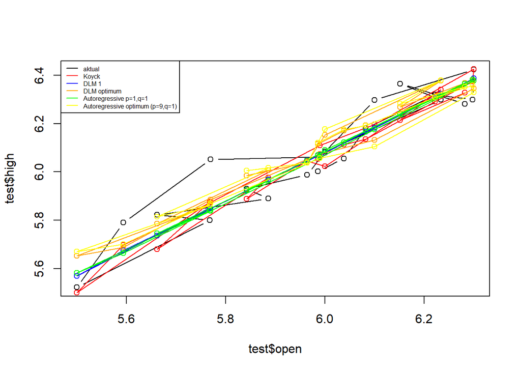

```r
par(mfrow=c(1,1))
plot(test$open, test$high, type="b", col="black")
points(test$open, fore.koyck$forecasts,col="red")
lines(test$open, fore.koyck$forecasts,col="red")
points(test$open, fore.dlm$forecasts,col="blue")
lines(test$open, fore.dlm$forecasts,col="blue")
points(test$open, fore.dlm2$forecasts,col="orange")
lines(test$open, fore.dlm2$forecasts,col="orange")
points(test$open, fore.ardl$forecasts,col="green")
lines(test$open, fore.ardl$forecasts,col="green")
points(test$open, frc.ardl.opt$forecasts,col="yellow")
lines(test$open, frc.ardl.opt$forecasts,col="yellow")
legend("topleft",c("aktual", "Koyck","DLM 1","DLM optimum","Autoregressive p=1,q=1", "Autoregressive optimum (p=9,q=1)"), lty=1, col=c("black","red","blue","orange","green","yellow"), cex=0.5)
```